# Modele nieliniowe - zadania — rozwiązanie

### Zadanie 1

Zadanie dotyczy zbioru `Boston`. Ustal zbiór walidacyjny (testowy) zawierający 20% losowo wybranych danych (ziarno generatora ustaw na swój numer albumu). Licząc błąd średniokwadratowy na tym zbiorze ustal optymalny stopień wielomianu (między 1 a 10) w regresji wielomianowej `medv` względem `lstat` (modele mają być uczone na danych nienależących do zbioru walidacyjnego). Optymalnym modelem jest ten, który uzyskuje najmniejszą estymatę błędu testowego.

```r
library(MASS)

data(Boston)

nr_albumu <- 123456  # <- zamień na swój numer albumu
set.seed(nr_albumu)

n <- nrow(Boston)
test_id <- sample(seq_len(n), size = floor(0.20 * n))

Boston_train <- Boston[-test_id, ]
Boston_test  <- Boston[test_id, ]

mse_poly <- sapply(1:10, function(deg) {
  fit <- lm(medv ~ poly(lstat, deg), data = Boston_train)
  pred <- predict(fit, newdata = Boston_test)
  mean((Boston_test$medv - pred)^2)
})

wyniki_poly <- data.frame(
  stopien = 1:10,
  MSE = mse_poly
)

wyniki_poly
```

```
##    stopien      MSE
## 1        1 39.85346
## 2        2 29.17987
## 3        3 27.39206
## 4        4 25.27429
## 5        5 24.04649
## 6        6 24.85558
## 7        7 24.97378
## 8        8 24.67036
## 9        9 24.49344
## 10      10 25.18015
```

```r
optymalny_stopien <- wyniki_poly$stopien[which.min(wyniki_poly$MSE)]
optymalny_stopien
```

```
## [1] 5
```

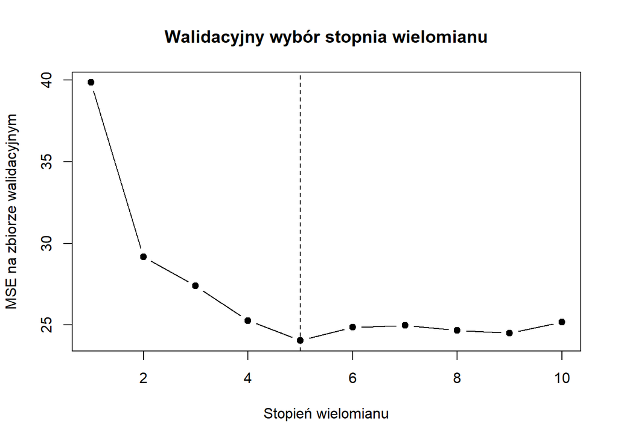

```r
plot(
  wyniki_poly$stopien, wyniki_poly$MSE,
  type = "b", pch = 19,
  xlab = "Stopień wielomianu",
  ylab = "MSE na zbiorze walidacyjnym",
  main = "Walidacyjny wybór stopnia wielomianu"
)
abline(v = optymalny_stopien, lty = 2)
```

Wniosek: optymalny jest ten stopień wielomianu, dla którego `MSE` w tabeli `wyniki_poly` jest najmniejsze. Wynik może się różnić w zależności od numeru albumu użytego jako ziarno generatora.

### Zadanie 2

Zadanie dotyczy zbioru danych `Abalone` z repozytorium UCI ML. Zawiera on dane z pomiarów cech fizycznych słuchotek (czyli uchowców). Interesuje nas zależność wieku osobnika wyrażona liczbą pierścieni `Rings` od pozostałych parametrów.

```r
# Wersja z pakietem ucimlrepo zgodna ze szkieletem zadania.
library(ucimlrepo)

abalone_file <- "abalone_uci.rds"
if (!file.exists(abalone_file)) {
  abalone_uci <- fetch_ucirepo("Abalone")
  saveRDS(abalone_uci, file = abalone_file)
} else {
  abalone_uci <- readRDS(abalone_file)
}

abalone <- abalone_uci$data$original
abalone$Sex <- as.factor(abalone$Sex)
head(abalone)
```

```
##   Sex Length Diameter Height Whole_weight Shucked_weight Viscera_weight
## 1   M  0.455    0.365  0.095       0.5140         0.2245         0.1010
## 2   M  0.350    0.265  0.090       0.2255         0.0995         0.0485
## 3   F  0.530    0.420  0.135       0.6770         0.2565         0.1415
## 4   M  0.440    0.365  0.125       0.5160         0.2155         0.1140
## 5   I  0.330    0.255  0.080       0.2050         0.0895         0.0395
## 6   I  0.425    0.300  0.095       0.3515         0.1410         0.0775
##   Shell_weight Rings
## 1        0.150    15
## 2        0.070     7
## 3        0.210     9
## 4        0.155    10
## 5        0.055     7
## 6        0.120     8
```

Zmienna `Whole_weight` jest praktycznie liniowo zależna od pozostałych parametrów wagi.

```r
lm(Whole_weight ~ Shucked_weight + Viscera_weight + Shell_weight, data = abalone) |>
  summary()
```

```
##
## Call:
## lm(formula = Whole_weight ~ Shucked_weight + Viscera_weight +
##     Shell_weight, data = abalone)
##
## Residuals:
##      Min       1Q   Median       3Q      Max
## -0.54690 -0.01708 -0.00195  0.00903  0.51721
##
## Coefficients:
##                 Estimate Std. Error t value Pr(>|t|)
## (Intercept)    -0.007830   0.001452  -5.393 7.32e-08 ***
## Shucked_weight  0.936560   0.009294 100.770  < 2e-16 ***
## Viscera_weight  1.111650   0.021079  52.737  < 2e-16 ***
## Shell_weight    1.252962   0.012802  97.876  < 2e-16 ***
## ---
## Signif. codes:  0 '***' 0.001 '**' 0.01 '*' 0.05 '.' 0.1 ' ' 1
##
## Residual standard error: 0.0469 on 4173 degrees of freedom
## Multiple R-squared:  0.9909, Adjusted R-squared:  0.9909
## F-statistic: 1.508e+05 on 3 and 4173 DF,  p-value: < 2.2e-16
```

Należy ją zatem usunąć z dalszej analizy.

```r
abalone_m <- subset(abalone, select = -Whole_weight)
```

Po pierwsze dopasuj model regresji Poissonowskiej (liczba pierścieni jest oczywiście całkowita).

```r
abalone_fit_0 <- glm(
  Rings ~ .,
  data = abalone_m,
  family = poisson(link = "log")
)

summary(abalone_fit_0)
```

```
##
## Call:
## glm(formula = Rings ~ ., family = poisson(link = "log"), data = abalone_m)
##
## Coefficients:
##                Estimate Std. Error z value Pr(>|z|)
## (Intercept)     1.47438    0.04702  31.358  < 2e-16 ***
## SexI           -0.10352    0.01515  -6.834 8.28e-12 ***
## SexM            0.00823    0.01150   0.716    0.474
## Length          0.25380    0.25928   0.979    0.328
## Diameter        1.50693    0.31460   4.790 1.67e-06 ***
## Height          1.04066    0.17157   6.066 1.31e-09 ***
## Shucked_weight -1.10956    0.06465 -17.164  < 2e-16 ***
## Viscera_weight -0.08167    0.13869  -0.589    0.556
## Shell_weight    1.44575    0.08367  17.280  < 2e-16 ***
## ---
## Signif. codes:  0 '***' 0.001 '**' 0.01 '*' 0.05 '.' 0.1 ' ' 1
##
## (Dispersion parameter for poisson family taken to be 1)
##
##     Null deviance: 4139.3  on 4176  degrees of freedom
## Residual deviance: 1894.6  on 4168  degrees of freedom
## AIC: 19047
##
## Number of Fisher Scoring iterations: 5
```

```r
drop1(abalone_fit_0, test = "Chisq")
```

```
## Single term deletions
##
## Model:
## Rings ~ Sex + Length + Diameter + Height + Shucked_weight + Viscera_weight +
##     Shell_weight
##                Df Deviance   AIC     LRT  Pr(>Chi)
## <none>              1894.5 19047
## Sex             2   1959.4 19108  64.804 8.473e-15 ***
## Length          1   1895.5 19046   0.960    0.3273
## Diameter        1   1917.4 19068  22.842 1.759e-06 ***
## Height          1   1924.4 19075  29.853 4.662e-08 ***
## Shucked_weight  1   2197.4 19348 302.819 < 2.2e-16 ***
## Viscera_weight  1   1894.9 19046   0.347    0.5559
## Shell_weight    1   2176.2 19327 281.662 < 2.2e-16 ***
## ---
## Signif. codes:  0 '***' 0.001 '**' 0.01 '*' 0.05 '.' 0.1 ' ' 1
```

Następnie usuń nieistotne predyktory (być może trzeba to będzie zrobić krokowo).

```r
# Z pełnego modelu nieistotne wychodzą kolejno: Viscera_weight, a potem Length.
# Sex zostaje jako cały czynnik, nawet jeśli jeden z poziomów samodzielnie
# nie ma istotnego współczynnika.

abalone_fit_1 <- update(abalone_fit_0, . ~ . - Viscera_weight)
summary(abalone_fit_1)
```

```
##
## Call:
## glm(formula = Rings ~ Sex + Length + Diameter + Height + Shucked_weight +
##     Shell_weight, family = poisson(link = "log"), data = abalone_m)
##
## Coefficients:
##                 Estimate Std. Error z value Pr(>|z|)
## (Intercept)     1.479039   0.046334  31.921  < 2e-16 ***
## SexI           -0.102494   0.015050  -6.810 9.74e-12 ***
## SexM            0.008612   0.011476   0.750    0.453
## Length          0.234450   0.257142   0.912    0.362
## Diameter        1.511886   0.314444   4.808 1.52e-06 ***
## Height          1.035384   0.171774   6.028 1.66e-09 ***
## Shucked_weight -1.130194   0.054344 -20.797  < 2e-16 ***
## Shell_weight    1.430668   0.079711  17.948  < 2e-16 ***
## ---
## Signif. codes:  0 '***' 0.001 '**' 0.01 '*' 0.05 '.' 0.1 ' ' 1
##
## (Dispersion parameter for poisson family taken to be 1)
##
##     Null deviance: 4139.3  on 4176  degrees of freedom
## Residual deviance: 1894.9  on 4169  degrees of freedom
## AIC: 19046
##
## Number of Fisher Scoring iterations: 5
```

```r
drop1(abalone_fit_1, test = "Chisq")
```

```
## Single term deletions
##
## Model:
## Rings ~ Sex + Length + Diameter + Height + Shucked_weight + Shell_weight
##                Df Deviance   AIC    LRT  Pr(>Chi)
## <none>              1894.9 19046
## Sex             2   1959.4 19106  64.49 9.892e-15 ***
## Length          1   1895.7 19044   0.83    0.3616
## Diameter        1   1917.9 19067  23.01 1.608e-06 ***
## Height          1   1924.5 19073  29.56 5.412e-08 ***
## Shucked_weight  1   2345.8 19495 450.91 < 2.2e-16 ***
## Shell_weight    1   2199.5 19348 304.57 < 2.2e-16 ***
## ---
## Signif. codes:  0 '***' 0.001 '**' 0.01 '*' 0.05 '.' 0.1 ' ' 1
```

```r
abalone_fit <- update(abalone_fit_1, . ~ . - Length)
summary(abalone_fit)
```

```
##
## Call:
## glm(formula = Rings ~ Sex + Diameter + Height + Shucked_weight +
##     Shell_weight, family = poisson(link = "log"), data = abalone_m)
##
## Coefficients:
##                 Estimate Std. Error z value Pr(>|z|)
## (Intercept)     1.493660   0.043436  34.388  < 2e-16 ***
## SexI           -0.101994   0.015042  -6.781 1.20e-11 ***
## SexM            0.008577   0.011476   0.747    0.455
## Diameter        1.765820   0.145858  12.106  < 2e-16 ***
## Height          1.037483   0.171485   6.050 1.45e-09 ***
## Shucked_weight -1.117980   0.052639 -21.239  < 2e-16 ***
## Shell_weight    1.430102   0.079698  17.944  < 2e-16 ***
## ---
## Signif. codes:  0 '***' 0.001 '**' 0.01 '*' 0.05 '.' 0.1 ' ' 1
##
## (Dispersion parameter for poisson family taken to be 1)
##
##     Null deviance: 4139.3  on 4176  degrees of freedom
## Residual deviance: 1895.7  on 4170  degrees of freedom
## AIC: 19044
##
## Number of Fisher Scoring iterations: 5
```

```r
drop1(abalone_fit, test = "Chisq")
```

```
## Single term deletions
##
## Model:
## Rings ~ Sex + Diameter + Height + Shucked_weight + Shell_weight
##                Df Deviance   AIC    LRT  Pr(>Chi)
## <none>              1895.7 19044
## Sex             2   1959.7 19104  63.97 1.282e-14 ***
## Diameter        1   2046.6 19193 150.87 < 2.2e-16 ***
## Height          1   1925.5 19072  29.77 4.865e-08 ***
## Shucked_weight  1   2365.1 19512 469.35 < 2.2e-16 ***
## Shell_weight    1   2200.1 19347 304.41 < 2.2e-16 ***
## ---
## Signif. codes:  0 '***' 0.001 '**' 0.01 '*' 0.05 '.' 0.1 ' ' 1
```

Finalny model Poissonowski bez składników nieliniowych ma więc postać:

```r
formula(abalone_fit)
```

```
## Rings ~ Sex + Diameter + Height + Shucked_weight + Shell_weight
```

Następnie sprawdź, czy lepszego modelu nie da się uzyskać przy pomocy nieliniowych transformacji predyktorów. W tym celu do wszystkich istotnych predyktorów **numerycznych** zastosuj nieparametryczne transformacje wygładzające (wygładzające funkcje sklejane albo regresję lokalną).

```r
library(gam)

abalone_n_fit_0 <- gam(
  Rings ~ Sex +
    s(Diameter, df = 6) +
    s(Height, df = 6) +
    s(Shucked_weight, df = 6) +
    s(Shell_weight, df = 6),
  data = abalone_m,
  family = poisson(link = "log")
)

summary(abalone_n_fit_0)
```

```
##
## Call: gam(formula = Rings ~ Sex + s(Diameter, df = 6) + s(Height, df = 6) +
##     s(Shucked_weight, df = 6) + s(Shell_weight, df = 6), family = poisson(link = "log"),
##     data = abalone_m)
## Deviance Residuals:
##     Min      1Q  Median      3Q     Max
## -2.9857 -0.4288 -0.1124  0.2717  3.9381
##
## (Dispersion Parameter for poisson family taken to be 1)
##
##     Null Deviance: 4139.3 on 4176 degrees of freedom
## Residual Deviance: 1676.48 on 4150 degrees of freedom
## AIC: 18865.15
##
## Number of Local Scoring Iterations: NA
##
## Anova for Parametric Effects
##                             Df  Sum Sq Mean Sq F value    Pr(>F)
## Sex                          2  674.34  337.17  791.06 < 2.2e-16 ***
## s(Diameter, df = 6)          1  555.72  555.72 1303.82 < 2.2e-16 ***
## s(Height, df = 6)            1  159.06  159.06  373.19 < 2.2e-16 ***
## s(Shucked_weight, df = 6)    1  245.87  245.87  576.86 < 2.2e-16 ***
## s(Shell_weight, df = 6)      1  699.81  699.81 1641.88 < 2.2e-16 ***
## Residuals                 4150 1768.83    0.43
## ---
## Signif. codes:  0 '***' 0.001 '**' 0.01 '*' 0.05 '.' 0.1 ' ' 1
##
## Anova for Nonparametric Effects
##                           Npar Df Npar Chisq    P(Chi)
## (Intercept)
## Sex
## s(Diameter, df = 6)             5     58.831  2.12e-11 ***
## s(Height, df = 6)               5     18.630  0.002252 **
## s(Shucked_weight, df = 6)       5     82.619  2.22e-16 ***
## s(Shell_weight, df = 6)         5    106.656 < 2.2e-16 ***
## ---
## Signif. codes:  0 '***' 0.001 '**' 0.01 '*' 0.05 '.' 0.1 ' ' 1
```

```r
anova(abalone_n_fit_0, test = "Chisq")
```

```
## Anova for Nonparametric Effects
##                           Npar Df Npar Chisq    P(Chi)
## (Intercept)
## Sex
## s(Diameter, df = 6)             5     58.831  2.12e-11 ***
## s(Height, df = 6)               5     18.630  0.002252 **
## s(Shucked_weight, df = 6)       5     82.619  2.22e-16 ***
## s(Shell_weight, df = 6)         5    106.656 < 2.2e-16 ***
## ---
## Signif. codes:  0 '***' 0.001 '**' 0.01 '*' 0.05 '.' 0.1 ' ' 1
```

Pozostaw w modelu transformacje tylko tych predyktorów, dla których odpowiedni test wykazał istotność części nieparametrycznej.

```r
abalone_n_fit <- gam(
  Rings ~ Sex + Diameter +
    s(Height, df = 6) +
    s(Shucked_weight, df = 6) +
    s(Shell_weight, df = 6),
  data = abalone_m,
  family = poisson(link = "log")
)

summary(abalone_n_fit)
```

```
##
## Call: gam(formula = Rings ~ Sex + Diameter + s(Height, df = 6) + s(Shucked_weight,
##     df = 6) + s(Shell_weight, df = 6), family = poisson(link = "log"),
##     data = abalone_m)
## Deviance Residuals:
##     Min      1Q  Median      3Q     Max
## -2.9167 -0.4333 -0.1174  0.2778  3.9296
##
## (Dispersion Parameter for poisson family taken to be 1)
##
##     Null Deviance: 4139.3 on 4176 degrees of freedom
## Residual Deviance: 1692.318 on 4154.999 degrees of freedom
## AIC: 18870.99
##
## Number of Local Scoring Iterations: NA
##
## Anova for Parametric Effects
##                             Df  Sum Sq Mean Sq F value    Pr(>F)
## Sex                          2  633.90  316.95  737.36 < 2.2e-16 ***
## Diameter                     1  500.95  500.95 1165.41 < 2.2e-16 ***
## s(Height, df = 6)            1  177.79  177.79  413.61 < 2.2e-16 ***
## s(Shucked_weight, df = 6)    1  262.47  262.47  610.61 < 2.2e-16 ***
## s(Shell_weight, df = 6)      1  704.55  704.55 1639.10 < 2.2e-16 ***
## Residuals                 4155 1786.00    0.43
## ---
## Signif. codes:  0 '***' 0.001 '**' 0.01 '*' 0.05 '.' 0.1 ' ' 1
##
## Anova for Nonparametric Effects
##                           Npar Df Npar Chisq    P(Chi)
## (Intercept)
## Sex
## Diameter
## s(Height, df = 6)               5     37.587 4.568e-07 ***
## s(Shucked_weight, df = 6)       5     92.957 < 2.2e-16 ***
## s(Shell_weight, df = 6)         5    121.878 < 2.2e-16 ***
## ---
## Signif. codes:  0 '***' 0.001 '**' 0.01 '*' 0.05 '.' 0.1 ' ' 1
```

```r
anova(abalone_n_fit, test = "Chisq")
```

```
## Anova for Nonparametric Effects
##                           Npar Df Npar Chisq    P(Chi)
## (Intercept)
## Sex
## Diameter
## s(Height, df = 6)               5     37.587 4.568e-07 ***
## s(Shucked_weight, df = 6)       5     92.957 < 2.2e-16 ***
## s(Shell_weight, df = 6)         5    121.878 < 2.2e-16 ***
## ---
## Signif. codes:  0 '***' 0.001 '**' 0.01 '*' 0.05 '.' 0.1 ' ' 1
```

Porównaj oba finalne modele przy pomocy testów ANOVA. Który model jest lepszy?

```r
anova(abalone_fit, abalone_n_fit, test = "Chisq")
```

```
## Analysis of Deviance Table
##
## Model 1: Rings ~ Sex + Diameter + Height + Shucked_weight + Shell_weight
## Model 2: Rings ~ Sex + Diameter + s(Height, df = 6) + s(Shucked_weight,
##     df = 6) + s(Shell_weight, df = 6)
##   Resid. Df Resid. Dev     Df Deviance  Pr(>Chi)
## 1      4170     1895.7
## 2      4155     1692.3 15.001   203.41 < 2.2e-16 ***
## ---
## Signif. codes:  0 '***' 0.001 '**' 0.01 '*' 0.05 '.' 0.1 ' ' 1
```

```r
# Ręcznie ta sama idea: test ilorazu wiarygodności na spadku dewiancji.
lr_stat <- abalone_fit$deviance - abalone_n_fit$deviance
df_diff <- abalone_fit$df.residual - abalone_n_fit$df.residual
p_value <- pchisq(lr_stat, df = df_diff, lower.tail = FALSE)

data.frame(
  model_liniowy_deviance = abalone_fit$deviance,
  model_nieliniowy_deviance = abalone_n_fit$deviance,
  roznica_dewiancji = lr_stat,
  roznica_df = df_diff,
  p_value = p_value
)
```

```
##   model_liniowy_deviance model_nieliniowy_deviance roznica_dewiancji roznica_df
## 1               1895.731                  1692.318          203.4125   15.00065
##       p_value
## 1 4.30452e-35
```

Wniosek: lepszy jest model z istotnymi składnikami nieliniowymi, bo istotnie zmniejsza dewiancję względem finalnego modelu Poissonowskiego bez wygładzeń.

Wykonaj PDP dla obu modeli.

```r
library(pdp)
library(ggplot2)

pred_rings <- function(object, newdata) {
  as.numeric(predict(object, newdata = newdata, type = "response"))
}

pdp_vars <- c("Sex", "Diameter", "Height", "Shucked_weight", "Shell_weight")

plot_pdp <- function(model, vars, title_prefix) {
  for (v in vars) {
    pd <- partial(
      object = model,
      pred.var = v,
      train = abalone_m,
      pred.fun = pred_rings,
      grid.resolution = 50,
      plot = FALSE
    )

    print(
      autoplot(pd, rug = TRUE, train = abalone_m) +
        labs(
          title = paste(title_prefix, v),
          y = "PDP: przewidywana liczba Rings"
        )
    )
  }
}
```

PDP dla modelu bez składników nieparametrycznych.

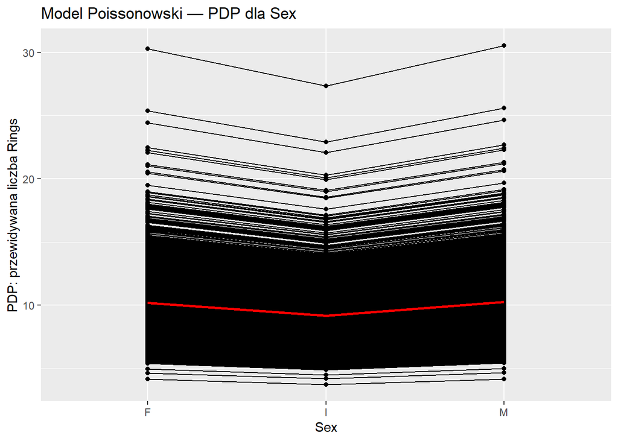

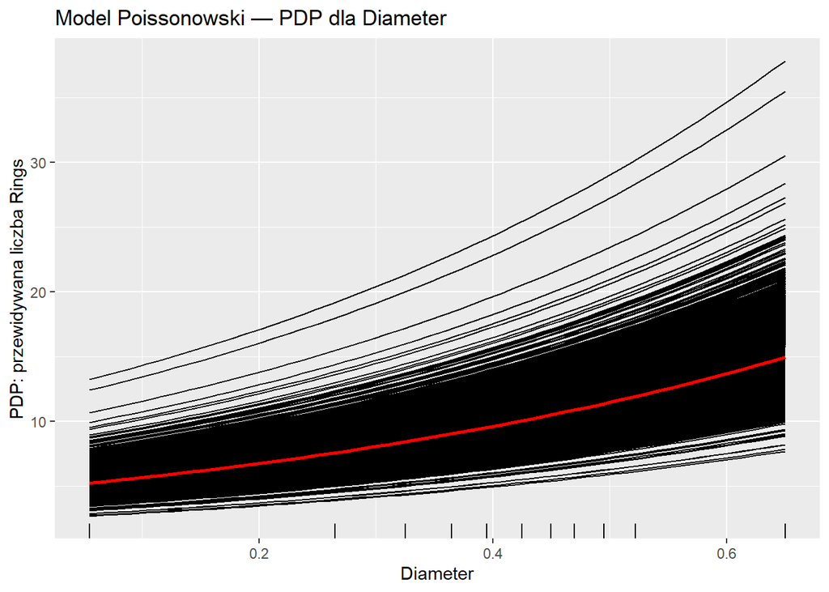

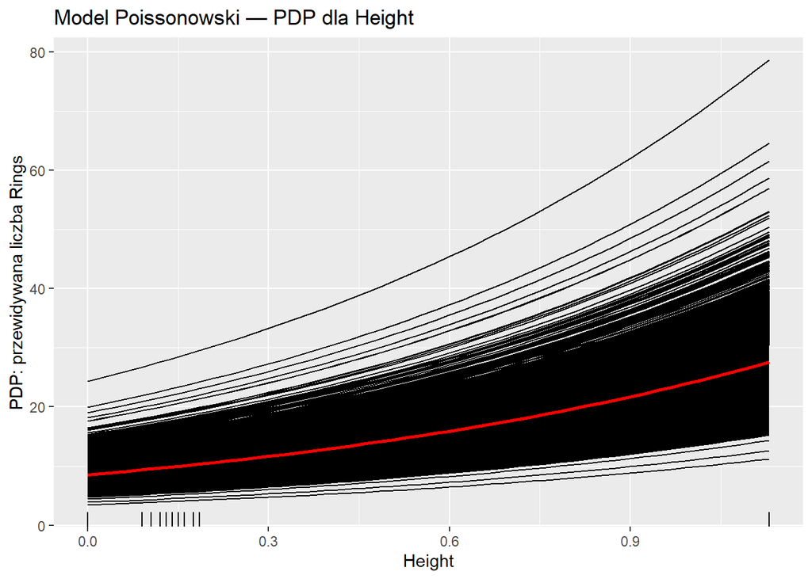

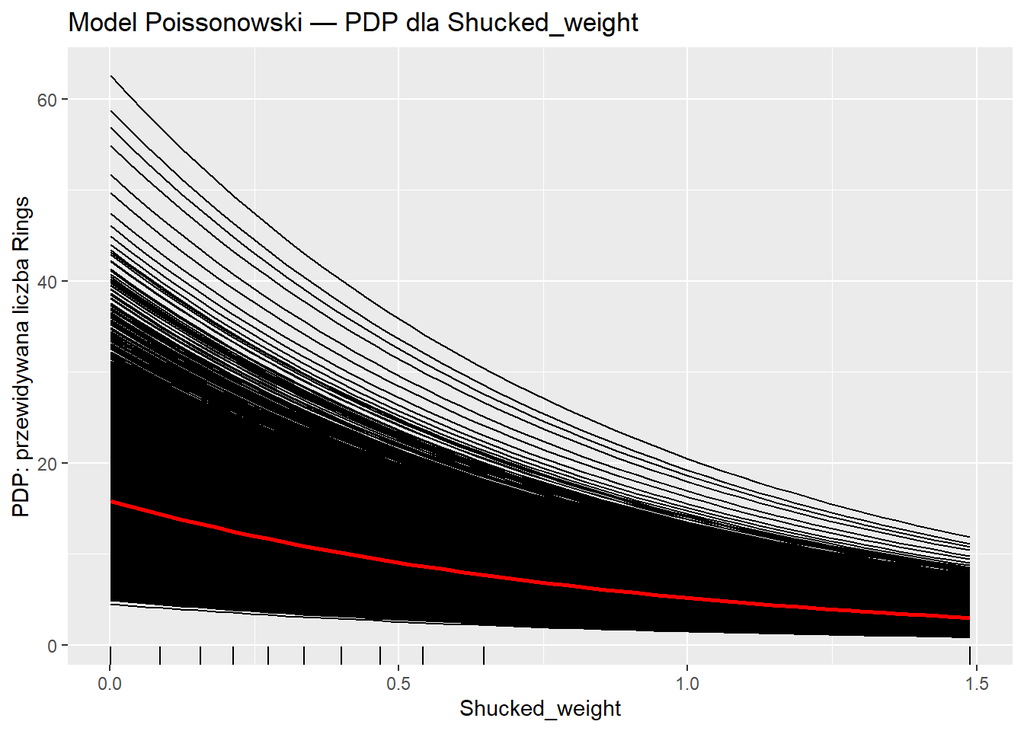

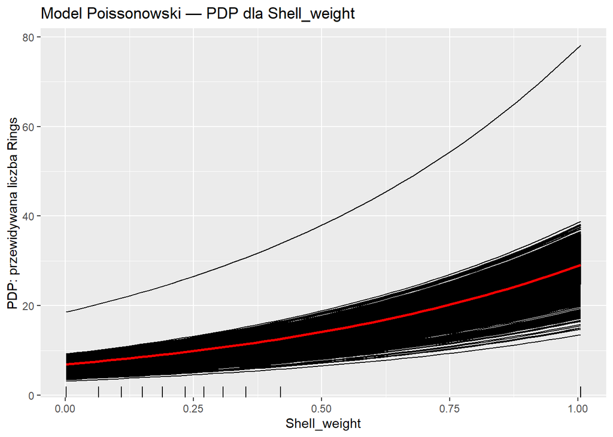

```r
plot_pdp(abalone_fit, pdp_vars, "Model Poissonowski — PDP dla")
```

PDP dla modelu ze składnikami nieparametrycznymi.

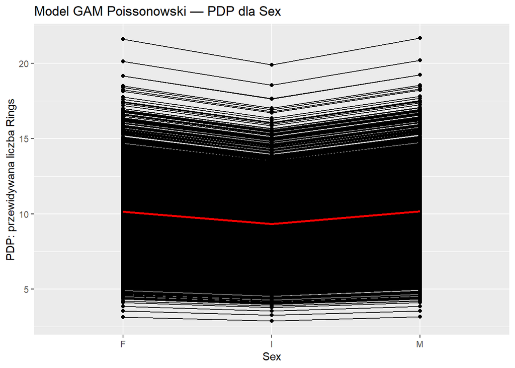

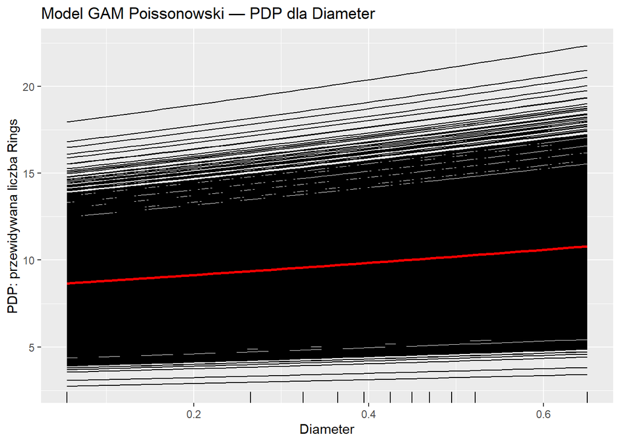

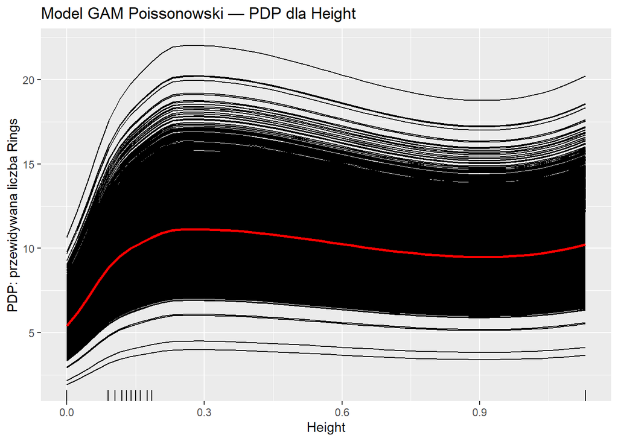

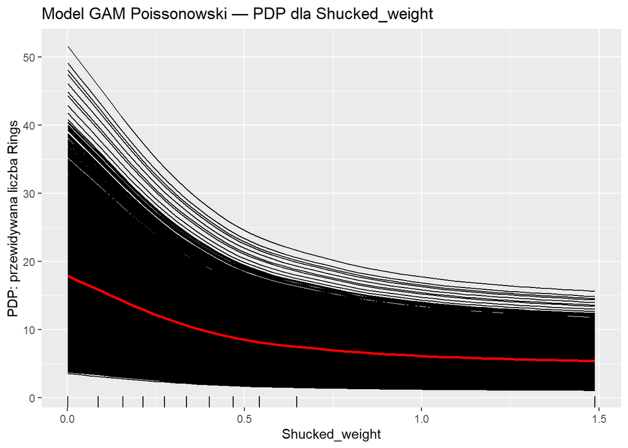

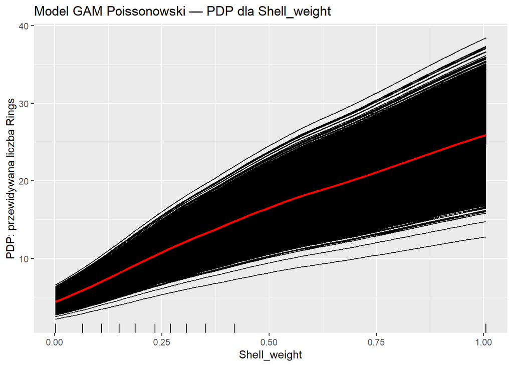

```r
plot_pdp(abalone_n_fit, pdp_vars, "Model GAM Poissonowski — PDP dla")
```

### Zagadnienia dla zainteresowanych

Zbiór zawiera dane wyraźnie odstające. Widać je na wykresach PDP (zmienność `Rings` względem `Height`).

- Ile jest takich obserwacji wyraźnie odstających (względem `Height`)? Które to są?

```r
# Dwie obserwacje mają Height = 0, a dwie mają Height skrajnie większe niż reszta.
height_out_id <- which(abalone_m$Height == 0 | abalone_m$Height > 0.4)
height_out_id
```

```
## [1] 1258 1418 2052 3997
```

```r
abalone_m[height_out_id, ]
```

```
##      Sex Length Diameter Height Shucked_weight Viscera_weight Shell_weight
## 1258   I  0.430    0.340  0.000         0.2065         0.0860       0.1150
## 1418   M  0.705    0.565  0.515         1.1075         0.4865       0.5120
## 2052   F  0.455    0.355  1.130         0.3320         0.1160       0.1335
## 3997   I  0.315    0.230  0.000         0.0575         0.0285       0.3505
##      Rings
## 1258     8
## 1418    10
## 2052     8
## 3997     6
```

Wniosek: są 4 takie obserwacje. W kolejności danych UCI są to wiersze: `1258`, `1418`, `2052`, `3997`.

- Czy modele zmieniają się istotnie po usunięciu tych obserwacji? W szczególności czy któreś składniki nieliniowe przestają być istotne?

```r
abalone_clean <- abalone_m[-height_out_id, ]

abalone_fit_clean_0 <- glm(
  Rings ~ .,
  data = abalone_clean,
  family = poisson(link = "log")
)

drop1(abalone_fit_clean_0, test = "Chisq")
```

```
## Single term deletions
##
## Model:
## Rings ~ Sex + Length + Diameter + Height + Shucked_weight + Viscera_weight +
##     Shell_weight
##                Df Deviance   AIC     LRT  Pr(>Chi)
## <none>              1855.7 18993
## Sex             2   1914.1 19047  58.392 2.091e-13 ***
## Length          1   1856.2 18991   0.574    0.4488
## Diameter        1   1871.1 19006  15.399 8.706e-05 ***
## Height          1   1922.0 19057  66.328 3.818e-16 ***
## Shucked_weight  1   2138.0 19273 282.292 < 2.2e-16 ***
## Viscera_weight  1   1857.2 18992   1.560    0.2117
## Shell_weight    1   2062.9 19198 207.195 < 2.2e-16 ***
## ---
## Signif. codes:  0 '***' 0.001 '**' 0.01 '*' 0.05 '.' 0.1 ' ' 1
```

```r
abalone_fit_clean <- glm(
  Rings ~ Sex + Diameter + Height + Shucked_weight + Shell_weight,
  data = abalone_clean,
  family = poisson(link = "log")
)
summary(abalone_fit_clean)
```

```
##
## Call:
## glm(formula = Rings ~ Sex + Diameter + Height + Shucked_weight +
##     Shell_weight, family = poisson(link = "log"), data = abalone_clean)
##
## Coefficients:
##                 Estimate Std. Error z value Pr(>|z|)
## (Intercept)     1.447163   0.044444  32.562  < 2e-16 ***
## SexI           -0.096038   0.015068  -6.374 1.84e-10 ***
## SexM            0.008627   0.011475   0.752    0.452
## Diameter        1.431214   0.156846   9.125  < 2e-16 ***
## Height          2.588658   0.319217   8.109 5.09e-16 ***
## Shucked_weight -1.112249   0.052708 -21.102  < 2e-16 ***
## Shell_weight    1.274233   0.085322  14.934  < 2e-16 ***
## ---
## Signif. codes:  0 '***' 0.001 '**' 0.01 '*' 0.05 '.' 0.1 ' ' 1
##
## (Dispersion parameter for poisson family taken to be 1)
##
##     Null deviance: 4136.7  on 4172  degrees of freedom
## Residual deviance: 1857.6  on 4166  degrees of freedom
## AIC: 18991
##
## Number of Fisher Scoring iterations: 4
```

```r
drop1(abalone_fit_clean, test = "Chisq")
```

```
## Single term deletions
##
## Model:
## Rings ~ Sex + Diameter + Height + Shucked_weight + Shell_weight
##                Df Deviance   AIC    LRT  Pr(>Chi)
## <none>              1857.6 18991
## Sex             2   1914.5 19043  56.85 4.516e-13 ***
## Diameter        1   1941.8 19073  84.24 < 2.2e-16 ***
## Height          1   1923.1 19054  65.52 5.739e-16 ***
## Shucked_weight  1   2320.8 19452 463.24 < 2.2e-16 ***
## Shell_weight    1   2069.4 19200 211.83 < 2.2e-16 ***
## ---
## Signif. codes:  0 '***' 0.001 '**' 0.01 '*' 0.05 '.' 0.1 ' ' 1
```

```r
abalone_n_clean_0 <- gam(
  Rings ~ Sex +
    s(Diameter, df = 6) +
    s(Height, df = 6) +
    s(Shucked_weight, df = 6) +
    s(Shell_weight, df = 6),
  data = abalone_clean,
  family = poisson(link = "log")
)

summary(abalone_n_clean_0)
```

```
##
## Call: gam(formula = Rings ~ Sex + s(Diameter, df = 6) + s(Height, df = 6) +
##     s(Shucked_weight, df = 6) + s(Shell_weight, df = 6), family = poisson(link = "log"),
##     data = abalone_clean)
## Deviance Residuals:
##     Min      1Q  Median      3Q     Max
## -3.0001 -0.4291 -0.1138  0.2738  3.9417
##
## (Dispersion Parameter for poisson family taken to be 1)
##
##     Null Deviance: 4136.674 on 4172 degrees of freedom
## Residual Deviance: 1670.698 on 4146 degrees of freedom
## AIC: 18843.68
##
## Number of Local Scoring Iterations: NA
##
## Anova for Parametric Effects
##                             Df  Sum Sq Mean Sq F value    Pr(>F)
## Sex                          2  712.00  356.00  837.18 < 2.2e-16 ***
## s(Diameter, df = 6)          1  611.50  611.50 1438.02 < 2.2e-16 ***
## s(Height, df = 6)            1  214.09  214.09  503.47 < 2.2e-16 ***
## s(Shucked_weight, df = 6)    1  257.38  257.38  605.27 < 2.2e-16 ***
## s(Shell_weight, df = 6)      1  666.59  666.59 1567.59 < 2.2e-16 ***
## Residuals                 4146 1763.02    0.43
## ---
## Signif. codes:  0 '***' 0.001 '**' 0.01 '*' 0.05 '.' 0.1 ' ' 1
##
## Anova for Nonparametric Effects
##                           Npar Df Npar Chisq    P(Chi)
## (Intercept)
## Sex
## s(Diameter, df = 6)             5     59.921 1.262e-11 ***
## s(Height, df = 6)               5      3.813    0.5766
## s(Shucked_weight, df = 6)       5     83.771 < 2.2e-16 ***
## s(Shell_weight, df = 6)         5    112.991 < 2.2e-16 ***
## ---
## Signif. codes:  0 '***' 0.001 '**' 0.01 '*' 0.05 '.' 0.1 ' ' 1
```

```r
anova(abalone_n_clean_0, test = "Chisq")
```

```
## Anova for Nonparametric Effects
##                           Npar Df Npar Chisq    P(Chi)
## (Intercept)
## Sex
## s(Diameter, df = 6)             5     59.921 1.262e-11 ***
## s(Height, df = 6)               5      3.813    0.5766
## s(Shucked_weight, df = 6)       5     83.771 < 2.2e-16 ***
## s(Shell_weight, df = 6)         5    112.991 < 2.2e-16 ***
## ---
## Signif. codes:  0 '***' 0.001 '**' 0.01 '*' 0.05 '.' 0.1 ' ' 1
```

Po usunięciu obserwacji odstających względem `Height` część nieliniowa dla `Height` przestaje być istotna. Zostają nieliniowości przede wszystkim dla `Shucked_weight` oraz `Shell_weight`.

```r
abalone_n_clean <- gam(
  Rings ~ Sex + Diameter + Height +
    s(Shucked_weight, df = 6) +
    s(Shell_weight, df = 6),
  data = abalone_clean,
  family = poisson(link = "log")
)

summary(abalone_n_clean)
```

```
##
## Call: gam(formula = Rings ~ Sex + Diameter + Height + s(Shucked_weight,
##     df = 6) + s(Shell_weight, df = 6), family = poisson(link = "log"),
##     data = abalone_clean)
## Deviance Residuals:
##     Min      1Q  Median      3Q     Max
## -2.9021 -0.4328 -0.1152  0.2760  3.9303
##
## (Dispersion Parameter for poisson family taken to be 1)
##
##     Null Deviance: 4136.674 on 4172 degrees of freedom
## Residual Deviance: 1695.945 on 4156 degrees of freedom
## AIC: 18848.93
##
## Number of Local Scoring Iterations: NA
##
## Anova for Parametric Effects
##                             Df  Sum Sq Mean Sq F value    Pr(>F)
## Sex                          2  672.68  336.34  781.59 < 2.2e-16 ***
## Diameter                     1  556.18  556.18 1292.46 < 2.2e-16 ***
## Height                       1  205.60  205.60  477.77 < 2.2e-16 ***
## s(Shucked_weight, df = 6)    1  284.41  284.41  660.93 < 2.2e-16 ***
## s(Shell_weight, df = 6)      1  647.61  647.61 1504.93 < 2.2e-16 ***
## Residuals                 4156 1788.44    0.43
## ---
## Signif. codes:  0 '***' 0.001 '**' 0.01 '*' 0.05 '.' 0.1 ' ' 1
##
## Anova for Nonparametric Effects
##                           Npar Df Npar Chisq    P(Chi)
## (Intercept)
## Sex
## Diameter
## Height
## s(Shucked_weight, df = 6)       5     97.354 < 2.2e-16 ***
## s(Shell_weight, df = 6)         5    150.205 < 2.2e-16 ***
## ---
## Signif. codes:  0 '***' 0.001 '**' 0.01 '*' 0.05 '.' 0.1 ' ' 1
```

```r
anova(abalone_fit_clean, abalone_n_clean, test = "Chisq")
```

```
## Analysis of Deviance Table
##
## Model 1: Rings ~ Sex + Diameter + Height + Shucked_weight + Shell_weight
## Model 2: Rings ~ Sex + Diameter + Height + s(Shucked_weight, df = 6) +
##     s(Shell_weight, df = 6)
##   Resid. Df Resid. Dev Df Deviance  Pr(>Chi)
## 1      4166     1857.6
## 2      4156     1696.0 10   161.65 < 2.2e-16 ***
## ---
## Signif. codes:  0 '***' 0.001 '**' 0.01 '*' 0.05 '.' 0.1 ' ' 1
```